# Clustering — Café Arábica

Variables dummies, K-means, Dendrograma y HDBSCAN · Coffee Quality Institute

Juan Sebastián Guayazán · Esteban Valente · Diego Nocua

26 de octubre de 2026

> **Propósito:** aplicar métodos de clustering a los 1.070 lotes de café arábica. Se incluyen variables numéricas (scores PCA) y variables categóricas convertidas a **dummies**. Se comparan tres enfoques: **K-means**, **Clustering jerárquico** (dendrograma) y **HDBSCAN**.

> **Nota sobre análisis de correspondencia:** el análisis de correspondencia es una técnica *diferente* — trabaja exclusivamente con tablas de frecuencias de variables dummy y **no** es equivalente a PCA ni a K-means. Se desarrollará en un documento aparte (`03-correspondencia/`).

# 1. Preparación de datos

El clustering se aplica sobre los **scores de las primeras componentes principales** (no sobre las variables originales), porque:

- Ya están estandarizados y transformados (Yeo-Johnson).
- Reducen el ruido: los últimos PCs capturan principalmente varianza residual.
- Facilitan la visualización: los clusters se pueden graficar directamente en el biplot.

```r
library(dplyr)
library(factoextra)
library(dbscan)      # incluye hdbscan()
library(ggplot2)
library(car)

# ── Pipeline idéntico al informe_despues.Rmd ──────────────────────────────────
data_raw <- read.csv("../data/arabica_data_cleaned.csv")

vars_originales <- c("Aroma", "Flavor", "Aftertaste", "Acidity", "Body",
                     "Balance", "Uniformity", "Clean.Cup", "Sweetness",
                     "Cupper.Points", "Moisture", "Category.One.Defects",
                     "Category.Two.Defects", "altitude_mean_meters")

datos_full <- data_raw %>%
  filter(!is.na(altitude_mean_meters),
         altitude_mean_meters > 0,
         altitude_mean_meters <= 3000) %>%
  select(all_of(vars_originales)) %>%
  filter(complete.cases(.)) %>%
  rename(
    Sabor           = Flavor,
    Retrogusto      = Aftertaste,
    Acidez          = Acidity,
    Cuerpo          = Body,
    Uniformidad     = Uniformity,
    Taza.Limpia     = Clean.Cup,
    Dulzura         = Sweetness,
    Puntaje.Catador = Cupper.Points,
    Humedad         = Moisture,
    Defectos.Cat1   = Category.One.Defects,
    Defectos.Cat2   = Category.Two.Defects,
    Altitud         = altitude_mean_meters
  )

yj_transform <- function(x, lambda) {
  if (lambda != 0) ((x + 1)^lambda - 1) / lambda else log(x + 1)
}
datos_full$Defectos.Cat2 <- yj_transform(datos_full$Defectos.Cat2, -0.217)

vars_11 <- setdiff(names(datos_full), c("Defectos.Cat1", "Defectos.Cat2", "Humedad"))
datos_t <- datos_full[, vars_11]

pt_11      <- powerTransform(datos_t, family = "yjPower")
lambdas_11 <- pmax(pmin(coef(pt_11, round = FALSE), 3), -3)
for (v in names(datos_t)) datos_t[[v]] <- yjPower(datos_t[[v]], lambdas_11[v])

pca <- prcomp(datos_t, center = TRUE, scale. = TRUE)

# Matriz de scores — se usará como X para clustering
X <- pca$x
cat("Dimensiones de X (scores PCA):", nrow(X), "lotes ×", ncol(X), "componentes\n")
```

```
## Dimensiones de X (scores PCA): 1070 lotes × 11 componentes
```

# 2. Variables categóricas → Dummies

K-means trabaja con distancias euclidianas, por lo que **no puede aplicarse directamente a variables de texto o factores**. La solución es convertirlas a variables binarias (dummies): una columna por categoría, con 1 si el lote pertenece a esa categoría y 0 si no.

El dataset tiene tres variables categóricas útiles con pocas categorías: `Processing.Method`, `Color` y `Country.of.Origin` (simplificada a los 5 países con más lotes para no generar decenas de columnas).

```r
library(fastDummies)   # dummy_cols()

# Seleccionar variables categóricas del CSV original
cat_vars <- data_raw %>%
  filter(!is.na(altitude_mean_meters),
         altitude_mean_meters > 0,
         altitude_mean_meters <= 3000) %>%
  filter(complete.cases(select(., all_of(vars_originales)))) %>%
  select(Processing.Method, Color, Country.of.Origin) %>%
  mutate(across(everything(), ~ ifelse(. == "" | is.na(.), "Desconocido", .)))

# Simplificar Country.of.Origin: top 5 países, el resto = "Otro"
top5_paises <- names(sort(table(cat_vars$Country.of.Origin), decreasing = TRUE)[1:5])
cat_vars$Pais <- ifelse(cat_vars$Country.of.Origin %in% top5_paises,
                        cat_vars$Country.of.Origin, "Otro")
cat_vars$Country.of.Origin <- NULL

cat("Categorías de Processing.Method:\n")
```

```
## Categorías de Processing.Method:
```

```r
print(table(cat_vars$Processing.Method))
```

```
##
##               Desconocido             Natural / Dry                     Other
##                        78                       177                        25
##    Pulped natural / honey Semi-washed / Semi-pulped              Washed / Wet
##                        10                        52                       728
```

```r
cat("\nCategorías de Color:\n")
```

```
##
## Categorías de Color:
```

```r
print(table(cat_vars$Color))
```

```
##
##   Blue-Green Bluish-Green  Desconocido        Green         None
##           69           81          139          738           43
```

```r
cat("\nTop 5 países + Otro:\n")
```

```
##
## Top 5 países + Otro:
```

```r
print(table(cat_vars$Pais))
```

```
##
##    Brazil  Colombia Guatemala    Mexico      Otro    Taiwan
##       104       149       151       232       364        70
```

```r
# Convertir a dummies (elimina primera columna de cada variable para evitar
# multicolinealidad perfecta — convención estándar)
dummies <- dummy_cols(cat_vars,
                      remove_first_dummy    = TRUE,
                      remove_selected_columns = TRUE)

cat("Dimensiones de la matriz de dummies:", nrow(dummies), "×", ncol(dummies), "\n")
```

```
## Dimensiones de la matriz de dummies: 1070 × 14
```

```r
cat("Columnas creadas:\n")
```

```
## Columnas creadas:
```

```r
print(names(dummies))
```

```
##  [1] "Processing.Method_Natural / Dry"
##  [2] "Processing.Method_Other"
##  [3] "Processing.Method_Pulped natural / honey"
##  [4] "Processing.Method_Semi-washed / Semi-pulped"
##  [5] "Processing.Method_Washed / Wet"
##  [6] "Color_Bluish-Green"
##  [7] "Color_Desconocido"
##  [8] "Color_Green"
##  [9] "Color_None"
## [10] "Pais_Colombia"
## [11] "Pais_Guatemala"
## [12] "Pais_Mexico"
## [13] "Pais_Otro"
## [14] "Pais_Taiwan"
```

```r
# Combinar scores PCA (variables numéricas transformadas) con dummies
X_num    <- scale(X[, 1:4])           # primeras 4 CPs
X_dum    <- scale(as.matrix(dummies)) # dummies escaladas
X_combinado <- cbind(X_num, X_dum)
cat("Matriz final para clustering:", nrow(X_combinado), "×", ncol(X_combinado),
    "(4 CPs + dummies)\n")
```

```
## Matriz final para clustering: 1070 × 18 (4 CPs + dummies)
```

```r
# Calcular k_codo aquí (necesario para el dendrograma que viene a continuación)
set.seed(42)
k_max <- 10
wss_tmp        <- sapply(1:k_max, function(k) kmeans(X_combinado, centers=k, nstart=15)$tot.withinss)
caidas_tmp     <- -diff(wss_tmp)
caidas_rel_tmp <- caidas_tmp / wss_tmp[-length(wss_tmp)]
k_codo         <- which.max(-diff(caidas_rel_tmp)) + 1
cat("k sugerido por el codo:", k_codo, "\n")
```

```
## k sugerido por el codo: 2
```

# 3. Dendrograma — Clustering jerárquico

El clustering jerárquico no requiere especificar k de antemano. Construye un árbol (dendrograma) mostrando cómo se van fusionando los lotes. El corte horizontal del árbol define los clusters.

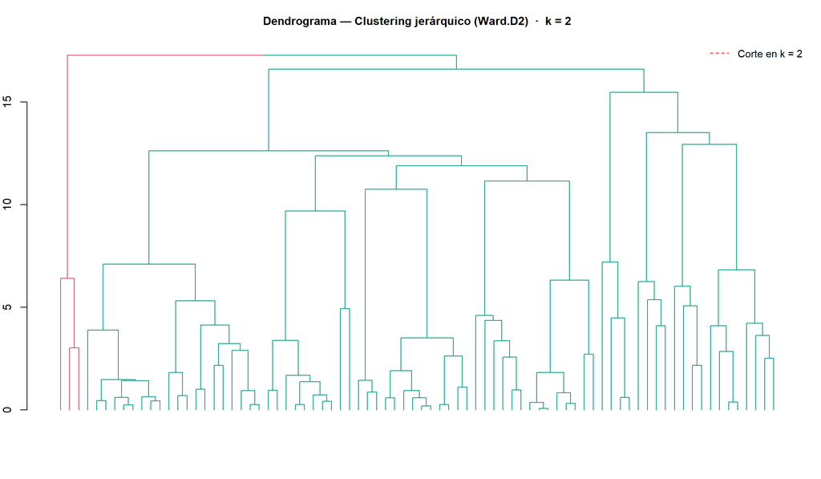

```r
# Muestra aleatoria de 80 lotes para que el dendrograma sea legible
set.seed(42)
idx_muestra <- sample(nrow(X_combinado), 80)
X_muestra   <- X_combinado[idx_muestra, ]

# Distancia euclídea + enlace de Ward (minimiza varianza intra-cluster)
dist_m  <- dist(X_muestra, method = "euclidean")
hc      <- hclust(dist_m, method = "ward.D2")

# Cortar en k_codo clusters
grupos_hc <- cutree(hc, k = k_codo)

# Dendrograma con clusters coloreados
library(dendextend)
dend <- as.dendrogram(hc)
dend <- color_branches(dend, k = k_codo)

par(mar = c(4, 2, 3, 1))
plot(dend,
     main  = paste0("Dendrograma — Clustering jerárquico (Ward.D2)  ·  k = ", k_codo),
     sub   = "Muestra de 80 lotes · variables numéricas + dummies",
     xlab  = "",
     ylab  = "Distancia euclídea",
     leaflab = "none",
     cex.main = 1)
abline(h = rev(hc$height)[k_codo - 1] * 1.05,
       col = "red", lty = 2, lwd = 1.5)
legend("topright", legend = paste("Corte en k =", k_codo),
       col = "red", lty = 2, bty = "n", cex = 0.9)
```

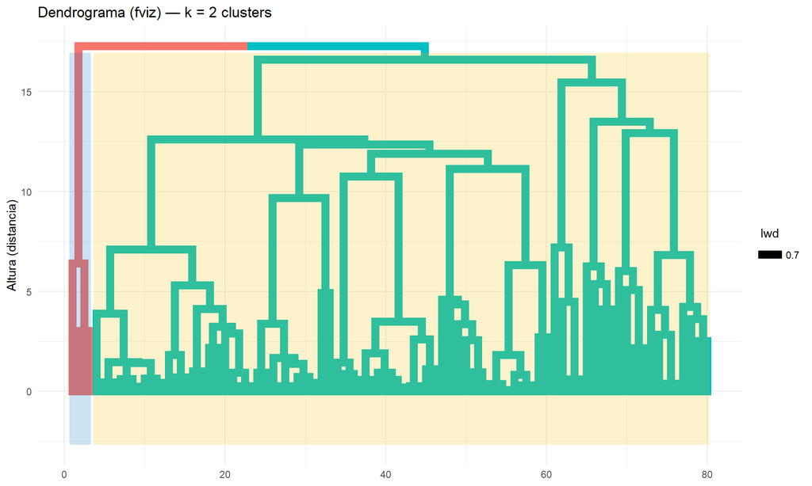

```r
# Versión más compacta con fviz_dend
fviz_dend(hc, k = k_codo,
          cex          = 0.4,
          rect         = TRUE,
          rect_fill    = TRUE,
          rect_border  = "jco",
          color_labels_by_k = TRUE,
          show_labels  = FALSE,
          main  = paste0("Dendrograma (fviz) — k = ", k_codo, " clusters"),
          sub   = "Muestra de 80 lotes · Ward.D2",
          ylab  = "Altura (distancia)") +
  theme_minimal()
```

# 4. K-means

## 4.1. Estandarización

K-means usa distancias euclidianas. La matriz `X_combinado` (CPs + dummies) ya está estandarizada en el paso anterior, así que se usa directamente.

```r
X_stand <- X_combinado   # ya escalado: CPs + dummies (k_codo calculado en chunk combinar)
```

## 4.2. Elección de k — método WSS (codo)

El método del codo calcula la **suma de cuadrados intra-cluster (WSS)** para cada k. A medida que k crece, WSS siempre baja; el punto óptimo es donde la curva “dobla” — a partir de ahí añadir más clusters da poco beneficio.

```r
set.seed(42)
k_max <- 10

# Calcular WSS para cada k
wss_vals <- sapply(1:k_max, function(k) {
  kmeans(X_stand, centers = k, nstart = 25)$tot.withinss
})

# Detectar el codo: mayor caída relativa de WSS
caidas      <- -diff(wss_vals)                 # cuánto baja WSS al pasar de k a k+1
caidas_rel  <- caidas / wss_vals[-length(wss_vals)]  # caída relativa
aceleracion <- diff(caidas_rel)                # segunda diferencia
k_codo      <- which.max(-aceleracion) + 1    # k donde la caída se frena más

cat("k sugerido por el método del codo:", k_codo, "\n")
```

```
## k sugerido por el método del codo: 8
```

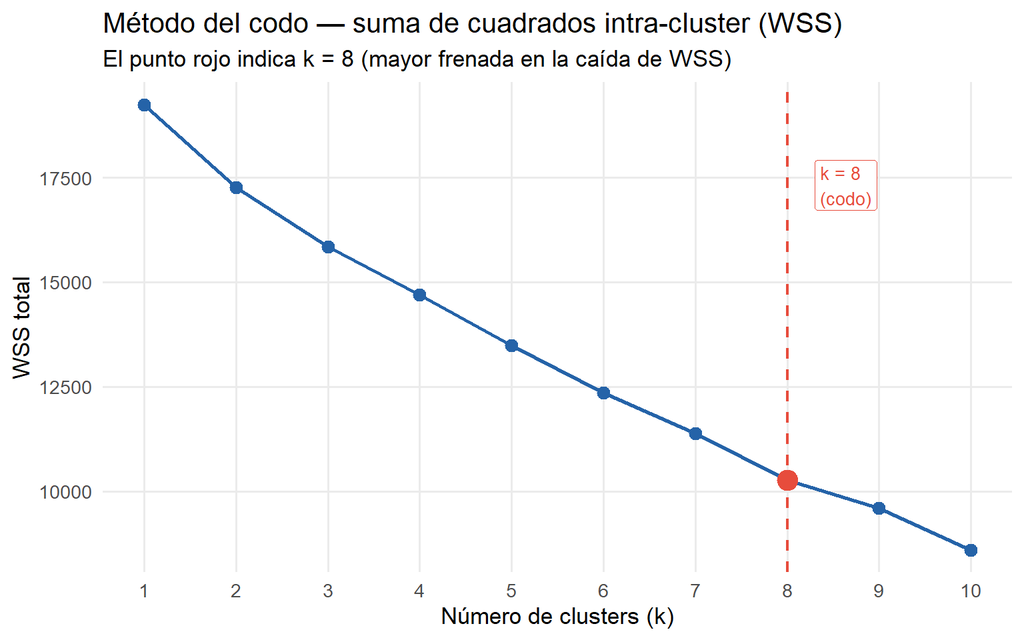

```r
# Gráfico con línea marcando el k elegido
wss_df <- data.frame(k = 1:k_max, wss = wss_vals)
ggplot(wss_df, aes(x = k, y = wss)) +
  geom_line(color = "#2563a8", linewidth = 1) +
  geom_point(color = "#2563a8", size = 3) +
  geom_point(data = wss_df[k_codo, ], aes(x = k, y = wss),
             color = "#e74c3c", size = 5) +
  geom_vline(xintercept = k_codo, linetype = "dashed",
             color = "#e74c3c", linewidth = 0.8) +
  annotate("label", x = k_codo + 0.3, y = max(wss_vals) * 0.9,
           label = paste0("k = ", k_codo, "\n(codo)"),
           color = "#e74c3c", size = 3.5, hjust = 0) +
  scale_x_continuous(breaks = 1:k_max) +
  labs(title    = "Método del codo — suma de cuadrados intra-cluster (WSS)",
       subtitle = paste0("El punto rojo indica k = ", k_codo, " (mayor frenada en la caída de WSS)"),
       x = "Número de clusters (k)",
       y = "WSS total") +
  theme_minimal(base_size = 13) +
  theme(panel.grid.minor = element_blank())
```

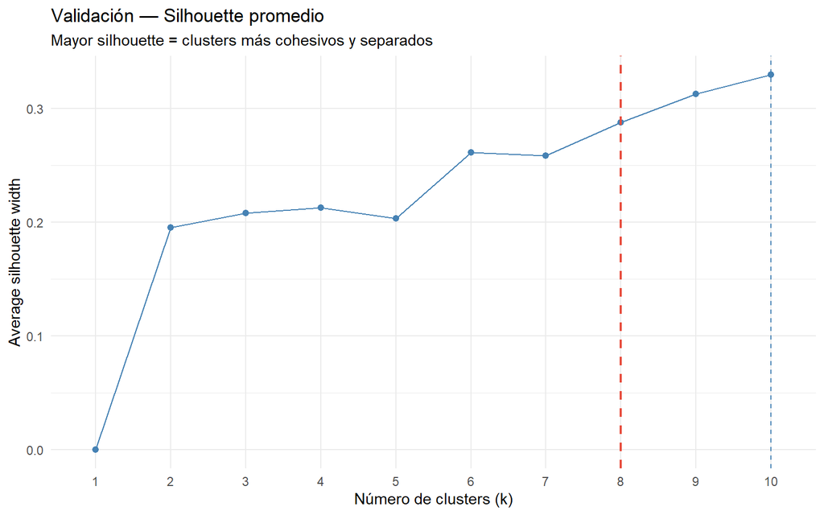

```r
# Silhouette como validación: mayor valor = mejor separación entre clusters
fviz_nbclust(X_stand, kmeans,
             method  = "silhouette",
             k.max   = k_max,
             nstart  = 25) +
  labs(title    = "Validación — Silhouette promedio",
       subtitle = "Mayor silhouette = clusters más cohesivos y separados",
       x = "Número de clusters (k)") +
  geom_vline(xintercept = k_codo, linetype = "dashed",
             color = "#e74c3c", linewidth = 0.8) +
  theme_minimal()
```

## 4.3. Ajuste del modelo final

```r
# k_optimo se deriva directamente del análisis del codo
k_optimo <- k_codo
cat("k seleccionado:", k_optimo, "\n")
```

```
## k seleccionado: 8
```

```r
set.seed(42)
km <- kmeans(X_stand, centers = k_optimo, nstart = 25)

cat("Tamaño de cada cluster:\n")
```

```
## Tamaño de cada cluster:
```

```r
print(km$size)
```

```
## [1] 135 176  97  25  78  42  10 507
```

```r
cat("\nRatio BSS/TSS (varianza explicada por clusters):",
    round(km$betweenss / km$totss * 100, 1), "%\n")
```

```
##
## Ratio BSS/TSS (varianza explicada por clusters): 46 %
```

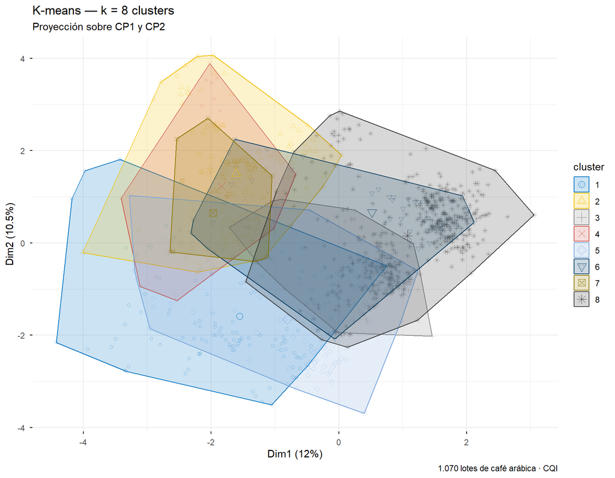

```r
fviz_cluster(km, data = X_stand,
             geom        = "point",
             ellipse.type = "convex",
             palette     = "jco",
             alpha       = 0.4,
             ggtheme     = theme_minimal()) +
  labs(title    = paste0("K-means — k = ", k_optimo, " clusters"),
       subtitle = "Proyección sobre CP1 y CP2",
       caption  = "1.070 lotes de café arábica · CQI")
```

## 4.5. Perfil de cada cluster

```r
datos_t$cluster_km <- factor(km$cluster)

perfil_km <- datos_t %>%
  group_by(cluster_km) %>%
  summarise(across(where(is.numeric), mean), .groups = "drop")

perfil_km
```

| cluster_km | Aroma | Sabor | Retrogusto | Acidez | Cuerpo | Balance | Uniformidad | Taza.Limpia | Dulzura | Puntaje.Catador | Altitud |
| --- | --- | --- | --- | --- | --- | --- | --- | --- | --- | --- | --- |
| 1 | 218.0421 | 116.0176 | 89.53757 | 213.6675 | 213.2631 | 64.31406 | 432.3644 | 432.5834 | 430.4531 | 46.12015 | 13195.117 |
| 2 | 212.5973 | 114.7437 | 87.37318 | 208.2385 | 209.2514 | 62.16126 | 433.3145 | 435.6817 | 437.6302 | 45.62713 | 8890.695 |
| 3 | 215.6687 | 114.9109 | 90.30444 | 212.0245 | 214.9453 | 65.63585 | 440.9756 | 439.5241 | 443.3333 | 46.43653 | 15458.552 |
| 4 | 202.4411 | 109.7217 | 84.65827 | 199.2350 | 199.1539 | 60.84643 | 421.4205 | 430.1600 | 430.1600 | 42.56735 | 9921.411 |
| 5 | 214.5700 | 113.6260 | 87.74070 | 210.1726 | 209.1634 | 62.73399 | 428.1862 | 429.8549 | 438.4466 | 45.43915 | 12313.970 |
| 6 | 196.1284 | 104.5612 | 79.07141 | 192.4940 | 194.2010 | 57.87747 | 418.5451 | 418.7782 | 441.5183 | 41.81069 | 10321.908 |
| 7 | 209.1069 | 112.4460 | 90.65712 | 205.6441 | 215.2867 | 62.83444 | 443.3333 | 443.3333 | 443.3333 | 45.57944 | 10246.002 |
| 8 | 207.9494 | 109.9031 | 84.14579 | 205.9471 | 201.2142 | 60.20669 | 427.2411 | 427.6126 | 435.6692 | 43.42447 | 11825.733 |

# 5. HDBSCAN

HDBSCAN (*Hierarchical Density-Based Spatial Clustering of Applications with Noise*) identifica clusters de densidad variable sin necesidad de especificar k. Los puntos en zonas de baja densidad se clasifican como **ruido** (cluster 0).

```r
# minPts equivale a min_cluster_size en Python's hdbscan
hdb <- hdbscan(X_stand, minPts = 20)

cat("Clusters encontrados (sin contar ruido):",
    length(unique(hdb$cluster[hdb$cluster > 0])), "\n")
```

```
## Clusters encontrados (sin contar ruido): 13
```

```r
cat("\nDistribución de puntos por cluster (0 = ruido):\n")
```

```
##
## Distribución de puntos por cluster (0 = ruido):
```

```r
print(table(hdb$cluster))
```

```
##
##   0   1   2   3   4   5   6   7   8   9  10  11  12  13
## 199  23  36  36  41  52  32  50  84 125  33  53 125 181
```

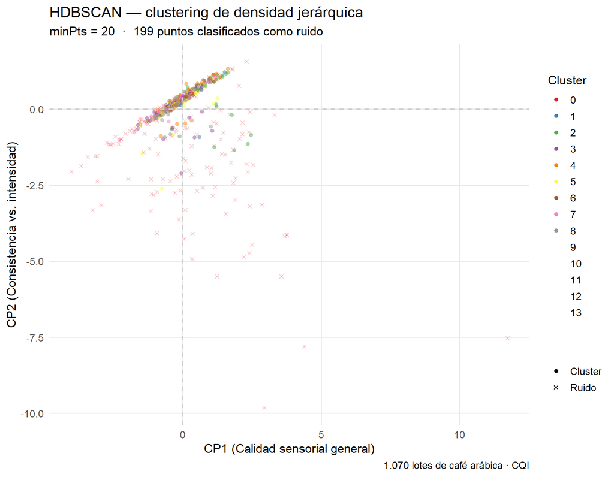

```r
scores_plot <- as.data.frame(X_stand[, 1:2])
colnames(scores_plot) <- c("CP1", "CP2")
scores_plot$cluster_hdb <- factor(hdb$cluster)
scores_plot$ruido       <- hdb$cluster == 0

ggplot(scores_plot, aes(x = CP1, y = CP2, color = cluster_hdb)) +
  geom_point(aes(alpha = ifelse(ruido, 0.2, 0.5), shape = ruido), size = 1.5) +
  scale_alpha_identity() +
  scale_shape_manual(values = c(`FALSE` = 16, `TRUE` = 4),
                     labels  = c("Cluster", "Ruido"),
                     name    = "") +
  scale_color_brewer(palette = "Set1", name = "Cluster") +
  geom_hline(yintercept = 0, linetype = "dashed", color = "#ccc") +
  geom_vline(xintercept = 0, linetype = "dashed", color = "#ccc") +
  labs(title    = "HDBSCAN — clustering de densidad jerárquica",
       subtitle = paste0("minPts = 20  ·  ",
                         sum(hdb$cluster == 0), " puntos clasificados como ruido"),
       caption  = "1.070 lotes de café arábica · CQI",
       x = "CP1 (Calidad sensorial general)",
       y = "CP2 (Consistencia vs. intensidad)") +
  theme_minimal(base_size = 13) +
  theme(panel.grid.minor = element_blank())
```

## 5.1. Perfil de cada cluster HDBSCAN

```r
datos_t$cluster_hdb <- factor(hdb$cluster)

perfil_hdb <- datos_t %>%
  filter(cluster_hdb != 0) %>%   # excluir ruido
  group_by(cluster_hdb) %>%
  summarise(across(where(is.numeric), mean), .groups = "drop")

perfil_hdb
```

| cluster_hdb | Aroma | Sabor | Retrogusto | Acidez | Cuerpo | Balance | Uniformidad | Taza.Limpia | Dulzura | Puntaje.Catador | Altitud |
| --- | --- | --- | --- | --- | --- | --- | --- | --- | --- | --- | --- |
| 1 | 203.2843 | 111.0127 | 85.62147 | 202.6890 | 201.9286 | 61.79081 | 433.8338 | 443.3333 | 443.3333 | 43.03406 | 9892.355 |
| 2 | 194.4501 | 103.0701 | 78.19243 | 189.2126 | 190.9192 | 57.28481 | 420.4829 | 429.1181 | 441.2158 | 41.43438 | 10125.821 |
| 3 | 216.9677 | 114.6413 | 87.15427 | 209.4469 | 205.7595 | 62.63157 | 428.7939 | 439.0982 | 439.0982 | 45.19623 | 10225.236 |
| 4 | 210.7539 | 111.2201 | 87.19527 | 200.2032 | 199.4771 | 59.64578 | 435.8960 | 443.3333 | 441.4740 | 43.27449 | 5174.225 |
| 5 | 214.8565 | 112.8315 | 87.61308 | 208.4692 | 206.3030 | 62.33089 | 438.9353 | 441.8673 | 438.9353 | 45.35736 | 13514.210 |
| 6 | 215.8452 | 112.8132 | 86.74525 | 198.5701 | 202.0037 | 64.92217 | 443.3333 | 443.3333 | 443.3333 | 45.15961 | 16342.292 |
| 7 | 215.1436 | 115.5980 | 89.70311 | 215.3472 | 212.4430 | 63.07573 | 443.3333 | 441.8087 | 443.3333 | 45.64365 | 12225.971 |
| 8 | 215.5051 | 114.7859 | 90.11671 | 211.9214 | 214.4072 | 65.61677 | 440.6107 | 442.4258 | 443.3333 | 46.43689 | 15516.992 |
| 9 | 209.7898 | 111.7424 | 82.94778 | 212.2851 | 201.9304 | 60.94615 | 435.4868 | 439.6742 | 437.8446 | 43.26441 | 12774.677 |
| 10 | 217.7141 | 115.0358 | 87.67038 | 210.2271 | 209.2106 | 61.97145 | 443.3333 | 443.3333 | 443.3333 | 45.68077 | 13716.563 |

[output cut: 3 more lines]

# 6. Comparación K-means vs HDBSCAN

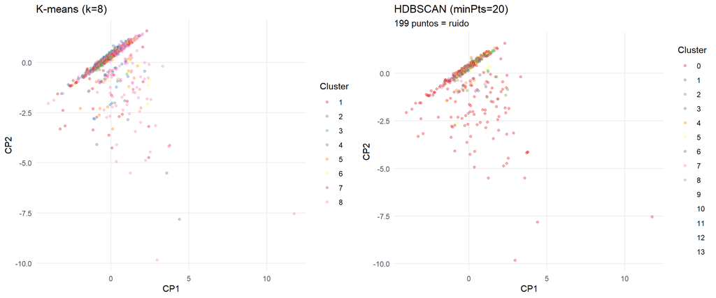

| Criterio | K-means | HDBSCAN |
| --- | --- | --- |
| Nº de clusters | Fijo (elegido por WSS) | Automático |
| Forma de clusters | Esférica (convexos) | Arbitraria |
| Manejo de ruido | No — todo punto pertenece a un cluster | Sí — puntos de baja densidad = ruido |
| Sensible a outliers | Sí | No |
| Parámetro principal | k | minPts |

```r
scores_comp <- as.data.frame(X_stand[, 1:2])
colnames(scores_comp) <- c("CP1", "CP2")
scores_comp$kmeans  <- factor(km$cluster)
scores_comp$hdbscan <- factor(hdb$cluster)

p1 <- ggplot(scores_comp, aes(CP1, CP2, color = kmeans)) +
  geom_point(alpha = 0.35, size = 1.2) +
  scale_color_brewer(palette = "Set1") +
  labs(title = paste0("K-means (k=", k_optimo, ")"), color = "Cluster") +
  theme_minimal() + theme(panel.grid.minor = element_blank())

p2 <- ggplot(scores_comp, aes(CP1, CP2, color = hdbscan)) +
  geom_point(alpha = 0.35, size = 1.2) +
  scale_color_brewer(palette = "Set1") +
  labs(title = "HDBSCAN (minPts=20)",
       subtitle = paste0(sum(hdb$cluster == 0), " puntos = ruido"),
       color = "Cluster") +
  theme_minimal() + theme(panel.grid.minor = element_blank())

gridExtra::grid.arrange(p1, p2, ncol = 2)
```